# Module 185

#### Hemi-module gene counts:

275 probesets in hemi-module A.  
39 probesets in hemi-module B.  
Note: While the mapping of probesets to genes is usually one-to-one, some genes are targeted by multiple probesets, some probesets target multiple genes, and some probesets do not target any genes (i.e., the region of the genome they match is no longer considered genic).

#### Contrast SVE:

Signed variance explained (SVE) provides an indication of how similar a set of fold changes are to a gene module’s weight vector. An SVE value of 0.3, for example, indicates that 30% of the variance explained by the entire module set is accounted for by the module in question. Shown here are the SVE values for this module across a compendium of fold changes (contrasts). Extreme SVE values (e.g., > 0.05) indicate that those contrasts specifically induce (orange dots) or specifically repress (blue dots) this module. Examining the experimental conditions being compared in such contrasts (see tables below the figure) may provide insight into the gene module’s function.

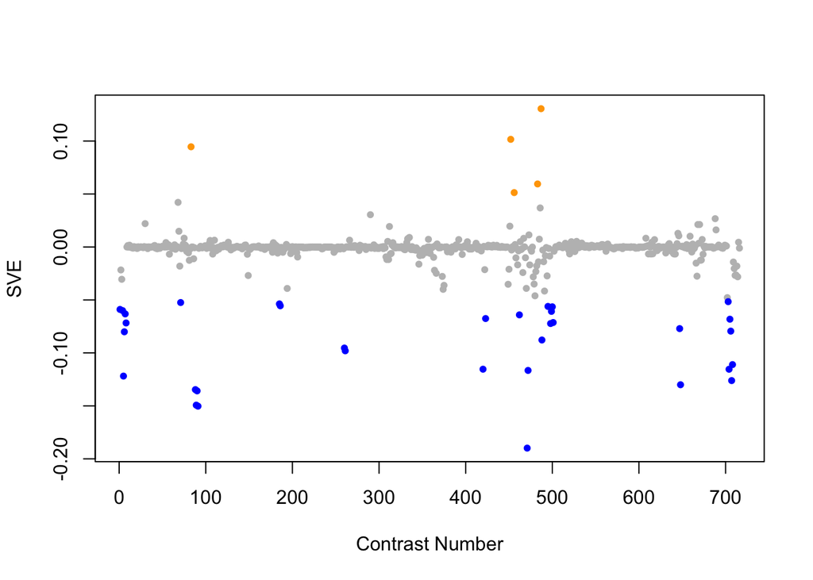

Positive SVE Contrasts:

|  | Contrast.Num | SVE | GEO.GSE | Cond.1 | Cond.2 | Mutation |
| --- | --- | --- | --- | --- | --- | --- |
| GSE23528A.s0t2.vs.s0t1 | 487 | 0.13 | GSE23528 | Adult at T6, non-entrained control time-series experiment 4 | Adult at T2, non-entrained control time-series experiment 4 |  |
| GSE25633.s1t1.vs.s2t1 | 452 | 0.10 | GSE25633 | WT#1 | daf-19,daf-12#1 | daf-19;daf-12 |
| GSE6563.s1t1.vs.s0t1 | 83 | 0.09 | GSE6563 | daf19(m86)_daf12(sa204) replicate 1 | daf19(WT)_daf12(sa204) replicate 1 | daf-19 |
| GSE23528A.s0t3.vs.s0t1 | 483 | 0.06 | GSE23528 | Adult at T10, non-entrained control time-series experiment 4 | Adult at T2, non-entrained control time-series experiment 4 |  |
| GSE24847.s1t2.vs.s1t1 | 456 | 0.05 | GSE24847 | young adult_24hr MWCNT exposure_rep1 | young adult_0h MWCNT exposure_rep1 |  |

Negative SVE Contrasts:

|  | Contrast.Num | SVE | GEO.GSE | Cond.1 | Cond.2 | Mutation |
| --- | --- | --- | --- | --- | --- | --- |
| GSE23528A.s1t2.vs.s0t2 | 471 | -0.19 | GSE23528 | Adult at T6 in LD, time-series experiment 3 | Adult at T6, non-entrained control time-series experiment 4 |  |
| GSE6547.s1t3.vs.s1t1 | 91 | -0.15 | GSE6547 | lin-35(n745) worms at L4 stage, first replicate | lin-35(n745) worms at embryonic stage, first replicate |  |
| GSE6547.s0t3.vs.s0t1 | 89 | -0.15 | GSE6547 | N2 (wt) worms at L4 stage, first replicate | N2 (wt) worms at embryonic stage, first replicate |  |
| GSE6547.s1t2.vs.s1t1 | 90 | -0.14 | GSE6547 | lin-35(n745) worms at L1 stage, first replicate | lin-35(n745) worms at embryonic stage, first replicate |  |
| GSE6547.s0t2.vs.s0t1 | 88 | -0.13 | GSE6547 | N2 (wt) worms at L1 stage, first replicate | N2 (wt) worms at embryonic stage, first replicate |  |
| GSE16753.s1t1.vs.s0t1 | 648 | -0.13 | GSE16753 | fer-1 (hc24ts) mutant young adult biological rep 1 | Wild-type young adult biological rep 3 | fer-1 |
| GSE11055.s1t7.vs.s1t1 | 707 | -0.13 | GSE11055 | L1-L2 larvae 15 hr after hatching in the presence of food | embryo 2 hr before hatching |  |
| GSE9897B.s2t1.vs.s0t1 | 5 | -0.12 | GSE9897 | Complex I RNAi Mutant 2 | Wildtype (control for RNAi) | Y45G12B.1 |
| GSE23528A.s2t2.vs.s0t2 | 472 | -0.12 | GSE23528 | Adult at T6 in WC, time-series experiment 1 | Adult at T6, non-entrained control time-series experiment 4 |  |
| GSE11055.s1t6.vs.s1t1 | 704 | -0.12 | GSE11055 | L1 larvae 12 hr after hatching in the presence of food | embryo 2 hr before hatching |  |
| GSE28494.s1t1.vs.s0t1 | 420 | -0.12 | GSE28494 | lin-54(n2990) embryo 1 | wild-type N2 embryo 1 | lin-54 |
| GSE11055.s1t8.vs.s1t1 | 708 | -0.11 | GSE11055 | L2 larvae 24 hr after hatching in the presence of food | embryo 2 hr before hatching |  |
| GSE41366A.s1t4.vs.s0t4 | 261 | -0.10 | GSE41366 | low_DDVP-2h_expose-26h_harvest-rep1 | control-2h_expose-26h_harvest-rep1 |  |
| GSE41366A.s2t4.vs.s0t4 | 260 | -0.10 | GSE41366 | high_DDVP-2h_expose-26h_harvest-rep1 | control-2h_expose-26h_harvest-rep1 |  |
| GSE23528B.s1t2.vs.s1t1 | 488 | -0.09 | GSE23528 | Adult at T30 in CC, time-series experiment 3 | Adult at T26 in CC, time-series experiment 3 |  |
| GSE9897B.s3t1.vs.s0t1 | 6 | -0.08 | GSE9897 | Complex I RNAi Mutant 3 | Wildtype (control for RNAi) | C34B2.8 |
| GSE11055.s1t5.vs.s1t1 | 706 | -0.08 | GSE11055 | L1 larvae 6 hr after hatching in the presence of food | embryo 2 hr before hatching |  |
| GSE16753.s2t1.vs.s0t1 | 647 | -0.08 | GSE16753 | fer-1 (hc1ts) mutant young adult biological rep 1 | Wild-type young adult biological rep 3 | fer-1 |
| GSE23013.s4t1.vs.s0t1 | 498 | -0.07 | GSE23013 | young adult_24hr Benzene exposure_rep1 | young adult_not exposed_rep1 |  |
| GSE9897B.s5t1.vs.s0t1 | 8 | -0.07 | GSE9897 | Complex I RNAi Mutant 5 | Wildtype (control for RNAi) | D2030.4 |
| GSE23013.s1t1.vs.s0t1 | 501 | -0.07 | GSE23013 | young adult_24hr Toluene exposure_rep1 | young adult_not exposed_rep1 |  |
| GSE11055.s1t4.vs.s1t1 | 705 | -0.07 | GSE11055 | L1 larvae 3 hr after hatching in the presence of food | embryo 2 hr before hatching |  |
| GSE28494.s0t2.vs.s0t1 | 423 | -0.07 | GSE28494 | wild-type N2 dissected germline 1 | wild-type N2 embryo 1 |  |
| GSE23528A.s2t3.vs.s0t3 | 462 | -0.06 | GSE23528 | Adult at T10 in WC, time-series experiment 1 | Adult at T10, non-entrained control time-series experiment 4 |  |
| GSE9897B.s4t1.vs.s0t1 | 7 | -0.06 | GSE9897 | Complex I RNAi Mutant 4 | Wildtype (control for RNAi) | Y56A3A.19 |
| GSE23013.s3t1.vs.s0t1 | 499 | -0.06 | GSE23013 | young adult_24hr BTF mix exposure_rep1 | young adult_not exposed_rep1 |  |
| GSE9897B.s1t1.vs.s0t1 | 4 | -0.06 | GSE9897 | Complex I RNAi Mutant 1 | Wildtype (control for RNAi) | F22D6.4 |
| GSE9897A.s1t1.vs.s0t1 | 1 | -0.06 | GSE9897 | Complex I missense mutant | Wildtype (control for missense) | gas-1 |
| GSE23013.s2t1.vs.s0t1 | 500 | -0.06 | GSE23013 | young adult_24hr Formaldehyde exposure_rep1 | young adult_not exposed_rep1 |  |
| GSE23528C.s1t4.vs.s1t1 | 495 | -0.06 | GSE23528 | Adult at T38 in DD, time-series experiment 2 | Adult at T26 in DD, time-series experiment 2 |  |
| GSE4766.s1t2.vs.s1t1 | 186 | -0.06 | GSE4766 | Pooled glp-1 C elegans young adults_rep1 | Pooled glp-1 C elegans embryos_bleach NaOH prep_rep1 |  |
| GSE4766.s1t3.vs.s1t1 | 185 | -0.05 | GSE4766 | Pooled glp-1 C elegans old adults_rep1 | Pooled glp-1 C elegans embryos_bleach NaOH prep_rep1 |  |
| GSE8462.s2t2.vs.s2t1 | 71 | -0.05 | GSE8462 | 24 hr Reference, biological rep 1 | 0 hr Reference, biological rep 1 |  |
| GSE11055.s1t3.vs.s1t1 | 703 | -0.05 | GSE11055 | L1 larvae 1 hr after hatching in the presence of food | embryo 2 hr before hatching |  |

$~$

#### Contrast SVE, Up-Regulated Genes Only:

Calculating SVE for up-regulated and down-regulated genes separately may be more informative in many cases than projecting the up- and down- gene sets together. This is due to the fact that the weight distribution of many modules is highly skewed, indicating that only one of the hemi-modules may be biologically meaningful (i.e., a set of genes are strongly correlated by only a few genes (or none) are strongly anti-correlated to that set.)

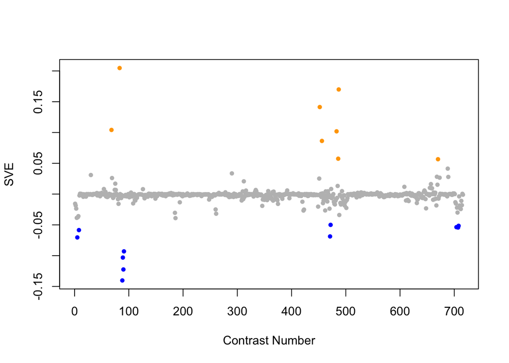

Positive SVE Contrasts:

|  | Contrast.Num | SVE | GEO.GSE | Cond.1 | Cond.2 | Mutation |
| --- | --- | --- | --- | --- | --- | --- |
| GSE6563.s1t1.vs.s0t1 | 83 | 0.20 | GSE6563 | daf19(m86)_daf12(sa204) replicate 1 | daf19(WT)_daf12(sa204) replicate 1 | daf-19 |
| GSE23528A.s0t2.vs.s0t1 | 487 | 0.17 | GSE23528 | Adult at T6, non-entrained control time-series experiment 4 | Adult at T2, non-entrained control time-series experiment 4 |  |
| GSE25633.s1t1.vs.s2t1 | 452 | 0.14 | GSE25633 | WT#1 | daf-19,daf-12#1 | daf-19;daf-12 |
| GSE8462.s2t1.vs.s1t1 | 68 | 0.10 | GSE8462 | 0 hr Reference, biological rep 1 | 0 hr muscle, biological rep 1 |  |
| GSE23528A.s0t3.vs.s0t1 | 483 | 0.10 | GSE23528 | Adult at T10, non-entrained control time-series experiment 4 | Adult at T2, non-entrained control time-series experiment 4 |  |
| GSE24847.s1t2.vs.s1t1 | 456 | 0.09 | GSE24847 | young adult_24hr MWCNT exposure_rep1 | young adult_0h MWCNT exposure_rep1 |  |
| GSE23528A.s0t6.vs.s0t1 | 486 | 0.06 | GSE23528 | Adult at T22, non-entrained control time-series experiment 4 | Adult at T2, non-entrained control time-series experiment 4 |  |
| GSE15016.s2t1.vs.s0t1 | 670 | 0.06 | GSE15016 | young adult_24hr NP exposure_rep1 | young adult_not exposured_rep1 |  |

Negative SVE Contrasts:

|  | Contrast.Num | SVE | GEO.GSE | Cond.1 | Cond.2 | Mutation |
| --- | --- | --- | --- | --- | --- | --- |
| GSE6547.s0t2.vs.s0t1 | 88 | -0.14 | GSE6547 | N2 (wt) worms at L1 stage, first replicate | N2 (wt) worms at embryonic stage, first replicate |  |
| GSE6547.s1t2.vs.s1t1 | 90 | -0.12 | GSE6547 | lin-35(n745) worms at L1 stage, first replicate | lin-35(n745) worms at embryonic stage, first replicate |  |
| GSE6547.s0t3.vs.s0t1 | 89 | -0.10 | GSE6547 | N2 (wt) worms at L4 stage, first replicate | N2 (wt) worms at embryonic stage, first replicate |  |
| GSE6547.s1t3.vs.s1t1 | 91 | -0.09 | GSE6547 | lin-35(n745) worms at L4 stage, first replicate | lin-35(n745) worms at embryonic stage, first replicate |  |
| GSE9897B.s2t1.vs.s0t1 | 5 | -0.07 | GSE9897 | Complex I RNAi Mutant 2 | Wildtype (control for RNAi) | Y45G12B.1 |
| GSE23528A.s1t2.vs.s0t2 | 471 | -0.07 | GSE23528 | Adult at T6 in LD, time-series experiment 3 | Adult at T6, non-entrained control time-series experiment 4 |  |
| GSE9897B.s5t1.vs.s0t1 | 8 | -0.06 | GSE9897 | Complex I RNAi Mutant 5 | Wildtype (control for RNAi) | D2030.4 |
| GSE11055.s1t7.vs.s1t1 | 707 | -0.05 | GSE11055 | L1-L2 larvae 15 hr after hatching in the presence of food | embryo 2 hr before hatching |  |
| GSE11055.s1t6.vs.s1t1 | 704 | -0.05 | GSE11055 | L1 larvae 12 hr after hatching in the presence of food | embryo 2 hr before hatching |  |
| GSE11055.s1t8.vs.s1t1 | 708 | -0.05 | GSE11055 | L2 larvae 24 hr after hatching in the presence of food | embryo 2 hr before hatching |  |
| GSE23528A.s2t2.vs.s0t2 | 472 | -0.05 | GSE23528 | Adult at T6 in WC, time-series experiment 1 | Adult at T6, non-entrained control time-series experiment 4 |  |

$~$

#### Contrast SVE, Down-Regulated Genes Only:

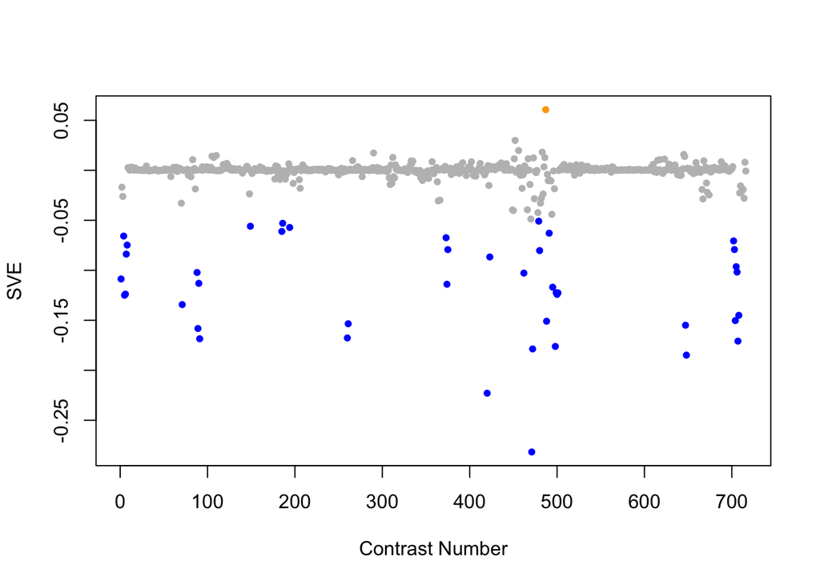

Positive SVE Contrasts:

|  | Contrast.Num | SVE | GEO.GSE | Cond.1 | Cond.2 | Mutation |
| --- | --- | --- | --- | --- | --- | --- |
| GSE23528A.s0t2.vs.s0t1 | 487 | 0.06 | GSE23528 | Adult at T6, non-entrained control time-series experiment 4 | Adult at T2, non-entrained control time-series experiment 4 |  |
| GSE25633.s1t1.vs.s2t1 | 452 | 0.03 | GSE25633 | WT#1 | daf-19,daf-12#1 | daf-19;daf-12 |
| GSE24847.s1t2.vs.s1t1 | 456 | 0.02 | GSE24847 | young adult_24hr MWCNT exposure_rep1 | young adult_0h MWCNT exposure_rep1 |  |
| GSE23528A.s0t3.vs.s0t1 | 483 | 0.02 | GSE23528 | Adult at T10, non-entrained control time-series experiment 4 | Adult at T2, non-entrained control time-series experiment 4 |  |
| GSE41366C.s1t5.vs.s0t5 | 290 | 0.02 | GSE41366 | low_DDVP-continuous_expose-26h_harvest-rep1 | control-continuous_expose-20h_harvest-rep1 |  |

Negative SVE Contrasts:

|  | Contrast.Num | SVE | GEO.GSE | Cond.1 | Cond.2 | Mutation |
| --- | --- | --- | --- | --- | --- | --- |
| GSE23528A.s1t2.vs.s0t2 | 471 | -0.28 | GSE23528 | Adult at T6 in LD, time-series experiment 3 | Adult at T6, non-entrained control time-series experiment 4 |  |
| GSE28494.s1t1.vs.s0t1 | 420 | -0.22 | GSE28494 | lin-54(n2990) embryo 1 | wild-type N2 embryo 1 | lin-54 |
| GSE16753.s1t1.vs.s0t1 | 648 | -0.18 | GSE16753 | fer-1 (hc24ts) mutant young adult biological rep 1 | Wild-type young adult biological rep 3 | fer-1 |
| GSE23528A.s2t2.vs.s0t2 | 472 | -0.18 | GSE23528 | Adult at T6 in WC, time-series experiment 1 | Adult at T6, non-entrained control time-series experiment 4 |  |
| GSE23013.s4t1.vs.s0t1 | 498 | -0.18 | GSE23013 | young adult_24hr Benzene exposure_rep1 | young adult_not exposed_rep1 |  |
| GSE11055.s1t7.vs.s1t1 | 707 | -0.17 | GSE11055 | L1-L2 larvae 15 hr after hatching in the presence of food | embryo 2 hr before hatching |  |
| GSE6547.s1t3.vs.s1t1 | 91 | -0.17 | GSE6547 | lin-35(n745) worms at L4 stage, first replicate | lin-35(n745) worms at embryonic stage, first replicate |  |
| GSE41366A.s2t4.vs.s0t4 | 260 | -0.17 | GSE41366 | high_DDVP-2h_expose-26h_harvest-rep1 | control-2h_expose-26h_harvest-rep1 |  |
| GSE6547.s0t3.vs.s0t1 | 89 | -0.16 | GSE6547 | N2 (wt) worms at L4 stage, first replicate | N2 (wt) worms at embryonic stage, first replicate |  |
| GSE16753.s2t1.vs.s0t1 | 647 | -0.15 | GSE16753 | fer-1 (hc1ts) mutant young adult biological rep 1 | Wild-type young adult biological rep 3 | fer-1 |
| GSE41366A.s1t4.vs.s0t4 | 261 | -0.15 | GSE41366 | low_DDVP-2h_expose-26h_harvest-rep1 | control-2h_expose-26h_harvest-rep1 |  |
| GSE23528B.s1t2.vs.s1t1 | 488 | -0.15 | GSE23528 | Adult at T30 in CC, time-series experiment 3 | Adult at T26 in CC, time-series experiment 3 |  |
| GSE11055.s1t6.vs.s1t1 | 704 | -0.15 | GSE11055 | L1 larvae 12 hr after hatching in the presence of food | embryo 2 hr before hatching |  |
| GSE11055.s1t8.vs.s1t1 | 708 | -0.15 | GSE11055 | L2 larvae 24 hr after hatching in the presence of food | embryo 2 hr before hatching |  |
| GSE8462.s2t2.vs.s2t1 | 71 | -0.13 | GSE8462 | 24 hr Reference, biological rep 1 | 0 hr Reference, biological rep 1 |  |
| GSE9897B.s2t1.vs.s0t1 | 5 | -0.12 | GSE9897 | Complex I RNAi Mutant 2 | Wildtype (control for RNAi) | Y45G12B.1 |
| GSE23013.s2t1.vs.s0t1 | 500 | -0.12 | GSE23013 | young adult_24hr Formaldehyde exposure_rep1 | young adult_not exposed_rep1 |  |
| GSE9897B.s3t1.vs.s0t1 | 6 | -0.12 | GSE9897 | Complex I RNAi Mutant 3 | Wildtype (control for RNAi) | C34B2.8 |
| GSE23013.s1t1.vs.s0t1 | 501 | -0.12 | GSE23013 | young adult_24hr Toluene exposure_rep1 | young adult_not exposed_rep1 |  |
| GSE23013.s3t1.vs.s0t1 | 499 | -0.12 | GSE23013 | young adult_24hr BTF mix exposure_rep1 | young adult_not exposed_rep1 |  |
| GSE23528C.s1t4.vs.s1t1 | 495 | -0.12 | GSE23528 | Adult at T38 in DD, time-series experiment 2 | Adult at T26 in DD, time-series experiment 2 |  |
| GSE35354A.s1t4.vs.s1t1 | 374 | -0.11 | GSE35354 | Q200_rep1 | Q control_rep1 |  |
| GSE6547.s1t2.vs.s1t1 | 90 | -0.11 | GSE6547 | lin-35(n745) worms at L1 stage, first replicate | lin-35(n745) worms at embryonic stage, first replicate |  |
| GSE9897A.s1t1.vs.s0t1 | 1 | -0.11 | GSE9897 | Complex I missense mutant | Wildtype (control for missense) | gas-1 |
| GSE23528A.s2t3.vs.s0t3 | 462 | -0.10 | GSE23528 | Adult at T10 in WC, time-series experiment 1 | Adult at T10, non-entrained control time-series experiment 4 |  |
| GSE6547.s0t2.vs.s0t1 | 88 | -0.10 | GSE6547 | N2 (wt) worms at L1 stage, first replicate | N2 (wt) worms at embryonic stage, first replicate |  |
| GSE11055.s1t5.vs.s1t1 | 706 | -0.10 | GSE11055 | L1 larvae 6 hr after hatching in the presence of food | embryo 2 hr before hatching |  |
| GSE11055.s1t4.vs.s1t1 | 705 | -0.10 | GSE11055 | L1 larvae 3 hr after hatching in the presence of food | embryo 2 hr before hatching |  |
| GSE28494.s0t2.vs.s0t1 | 423 | -0.09 | GSE28494 | wild-type N2 dissected germline 1 | wild-type N2 embryo 1 |  |
| GSE9897B.s4t1.vs.s0t1 | 7 | -0.08 | GSE9897 | Complex I RNAi Mutant 4 | Wildtype (control for RNAi) | Y56A3A.19 |
| GSE23528A.s2t5.vs.s2t1 | 480 | -0.08 | GSE23528 | Adult at T18 in WC, time-series experiment 1 | Adult at T2 in WC, time-series experiment 1 |  |
| GSE35354A.s1t2.vs.s1t1 | 375 | -0.08 | GSE35354 | Q50_rep1 | Q control_rep1 |  |
| GSE11055.s1t3.vs.s1t1 | 703 | -0.08 | GSE11055 | L1 larvae 1 hr after hatching in the presence of food | embryo 2 hr before hatching |  |
| GSE9897B.s5t1.vs.s0t1 | 8 | -0.07 | GSE9897 | Complex I RNAi Mutant 5 | Wildtype (control for RNAi) | D2030.4 |
| GSE11055.s1t2.vs.s1t1 | 702 | -0.07 | GSE11055 | L1 larvae 0 hr after hatching in the presence of food | embryo 2 hr before hatching |  |
| GSE35354A.s1t3.vs.s1t1 | 373 | -0.07 | GSE35354 | Q100_rep1 | Q control_rep1 |  |
| GSE9897B.s1t1.vs.s0t1 | 4 | -0.07 | GSE9897 | Complex I RNAi Mutant 1 | Wildtype (control for RNAi) | F22D6.4 |
| GSE23528B.s1t5.vs.s1t1 | 491 | -0.06 | GSE23528 | Adult at T42 in CC, time-series experiment 3 | Adult at T26 in CC, time-series experiment 3 |  |
| GSE4766.s1t3.vs.s1t1 | 185 | -0.06 | GSE4766 | Pooled glp-1 C elegans old adults_rep1 | Pooled glp-1 C elegans embryos_bleach NaOH prep_rep1 |  |
| GSE44318.s1t1.vs.s0t1 | 194 | -0.06 | GSE44318 | 13L peptide [SL12] | NGM [SL1] |  |
| GSE48347.s1t1.vs.s0t1 | 149 | -0.06 | GSE48347 | smo1_embryo_rep1 | WT_embryo_rep1 | smo-1 |
| GSE4766.s1t2.vs.s1t1 | 186 | -0.05 | GSE4766 | Pooled glp-1 C elegans young adults_rep1 | Pooled glp-1 C elegans embryos_bleach NaOH prep_rep1 |  |
| GSE23528A.s2t4.vs.s2t1 | 479 | -0.05 | GSE23528 | Adult at T14 in WC, time-series experiment 1 | Adult at T2 in WC, time-series experiment 1 |  |

$~$

$~$

#### GO Term Enrichment:

This analysis tests each hemi-module for enrichment of specific GO terms. Only gene-level annotations (e.g., as would be found on the gene’s page in Wormbase) are tested - the hierarchical structure of the GO ontology is not taken into account.

*Note: At least the top two most enriched terms from each GO domain (BP/MF/CC) are shown, even when not statistically significant.*

##### Enriched GO terms: Hemi-module A

| ID | GO.Term | GO Domain | Raw p-value | Adj p-value |
| --- | --- | --- | --- | --- |
| [GO_1904491](http://amigo.geneontology.org/amigo/term/GO:1904491) | protein localization to ciliary transition zone | BP | 6.80e-10 | 2.48e-06 |
| [GO_1905515](http://amigo.geneontology.org/amigo/term/GO:1905515) | non-motile cilium assembly | BP | 4.54e-07 | 8.26e-04 |
| [GO_0000981](http://amigo.geneontology.org/amigo/term/GO:0000981) | DNA-binding transcription factor activity, RNA polymerase II-specific | MF | 4.52e-06 | 9.23e-03 |
| [GO_0005509](http://amigo.geneontology.org/amigo/term/GO:0005509) | calcium ion binding | MF | 1.55e-04 | 1.58e-01 |
| [GO_0035869](http://amigo.geneontology.org/amigo/term/GO:0035869) | ciliary transition zone | CC | 9.83e-10 | 9.12e-07 |
| [GO_0005930](http://amigo.geneontology.org/amigo/term/GO:0005930) | axoneme | CC | 1.01e-05 | 4.67e-03 |
| [GO_0042995](http://amigo.geneontology.org/amigo/term/GO:0042995) | cell projection | CC | 1.55e-04 | 4.78e-02 |
| [GO_0060170](http://amigo.geneontology.org/amigo/term/GO:0060170) | ciliary membrane | CC | 2.34e-04 | 5.43e-02 |

##### Enriched GO terms: Hemi-module B

| ID | GO.Term | GO Domain | Raw p-value | Adj p-value |
| --- | --- | --- | --- | --- |
| [GO_0042338](http://amigo.geneontology.org/amigo/term/GO:0042338) | cuticle development involved in collagen and cuticulin-based cuticle molting cycle | BP | 5.53e-12 | 2.01e-08 |
| [GO_0043413](http://amigo.geneontology.org/amigo/term/GO:0043413) | macromolecule glycosylation | BP | 7.82e-04 | 7.83e-01 |
| [GO_0042302](http://amigo.geneontology.org/amigo/term/GO:0042302) | structural constituent of cuticle | MF | 3.08e-14 | 6.29e-11 |
| [GO_0042329](http://amigo.geneontology.org/amigo/term/GO:0042329) | structural constituent of collagen and cuticulin-based cuticle | MF | 5.96e-09 | 6.09e-06 |
| [GO_0005581](http://amigo.geneontology.org/amigo/term/GO:0005581) | collagen trimer | CC | 1.09e-09 | 1.01e-06 |
| [GO_0060102](http://amigo.geneontology.org/amigo/term/GO:0060102) | collagen and cuticulin-based cuticle extracellular matrix | CC | 3.84e-06 | 1.78e-03 |

$~$

$~$

#### Tissue Enrichment:

This analysis tests each hemi-module for enrichment of genes associated with anatomy terms. Negative enrichment scores indicate fewer hemi-module genes than expected by random chance were associated with the anatomy term in question.

##### Enriched tissues: Hemi-module A

| ID | Anatomy.Term | Definition | Raw p-value | Adj p-value |
| --- | --- | --- | --- | --- |
| [WBbt_0006816](https://wormbase.org/species/all/anatomy_term/WBbt:0006816) | ciliated neuron | neuron type, neurons that have ciliated nerve endings. | 6.57e-06 | 1.60e-02 |
| [WBbt_0005117](https://wormbase.org/species/all/anatomy_term/WBbt:0005117) | inner labial neuron | neuron type, member of a set of 12 neurons of the inner labial sensilla. | 3.42e-05 | 4.16e-02 |

##### Enriched tissues: Hemi-module B

No significant annotations.

$~$

$~$

#### HOMER promoter motif enrichment:

This analysis tests each hemi-module for enrichment of 108 known *C. elegans* transcription factor binding site motifs (see [108 CE motifs](https://katiepod.github.io//all.worm.motifs.html)) using the HOMER (Hypergeometric Optimization of Motif EnRichment) software (see [PMID:20513432](https://pubmed.ncbi.nlm.nih.gov/20513432)). HOMER was run using default parameters on sequences 1 kb upstream of the transcription start site.

##### Motif enrichment: Hemi-module A

Total target sequences = 235  
Total background sequences = 39849  
* - possible false positive

Rank

Motif

P-value

log P-pvalue

% of Targets

% of Background

STD(Bg STD)

Best Match/Details

Motif File

1

[figure not shown]

1e-15

-3.463e+01

8.09%

0.58%

255.3bp (352.3bp)

POL008.1_DCE_S_I/Jaspar(0.550)  
[More Information](https://katiepod.github.io/HomerResults/m185_a_hemi_genes.txt.out.1kb/homerResults/motif1.info.html) | [Similar Motifs Found](https://katiepod.github.io/HomerResults/m185_a_hemi_genes.txt.out.1kb/homerResults/motif1.similar.html)

[motif file (matrix)](https://katiepod.github.io/HomerResults/m185_a_hemi_genes.txt.out.1kb/homerResults/motif1.motif)

2

[figure not shown]

1e-12

-2.821e+01

17.87%

4.90%

292.5bp (310.2bp)

unc-86/MA0926.1/Jaspar(0.573)  
[More Information](https://katiepod.github.io/HomerResults/m185_a_hemi_genes.txt.out.1kb/homerResults/motif2.info.html) | [Similar Motifs Found](https://katiepod.github.io/HomerResults/m185_a_hemi_genes.txt.out.1kb/homerResults/motif2.similar.html)

[motif file (matrix)](https://katiepod.github.io/HomerResults/m185_a_hemi_genes.txt.out.1kb/homerResults/motif2.motif)

3 *

[figure not shown]

1e-11

-2.690e+01

7.23%

0.69%

293.9bp (286.3bp)

daf-16/MA1446.1/Jaspar(0.483)  
[More Information](https://katiepod.github.io/HomerResults/m185_a_hemi_genes.txt.out.1kb/homerResults/motif3.info.html) | [Similar Motifs Found](https://katiepod.github.io/HomerResults/m185_a_hemi_genes.txt.out.1kb/homerResults/motif3.similar.html)

[motif file (matrix)](https://katiepod.github.io/HomerResults/m185_a_hemi_genes.txt.out.1kb/homerResults/motif3.motif)

4 *

[figure not shown]

1e-11

-2.591e+01

8.51%

1.11%

285.4bp (323.5bp)

POL003.1_GC-box/Jaspar(0.597)  
[More Information](https://katiepod.github.io/HomerResults/m185_a_hemi_genes.txt.out.1kb/homerResults/motif4.info.html) | [Similar Motifs Found](https://katiepod.github.io/HomerResults/m185_a_hemi_genes.txt.out.1kb/homerResults/motif4.similar.html)

[motif file (matrix)](https://katiepod.github.io/HomerResults/m185_a_hemi_genes.txt.out.1kb/homerResults/motif4.motif)

5 *

[figure not shown]

1e-10

-2.511e+01

6.81%

0.66%

253.7bp (324.7bp)

POL005.1_DPE/Jaspar(0.580)  
[More Information](https://katiepod.github.io/HomerResults/m185_a_hemi_genes.txt.out.1kb/homerResults/motif5.info.html) | [Similar Motifs Found](https://katiepod.github.io/HomerResults/m185_a_hemi_genes.txt.out.1kb/homerResults/motif5.similar.html)

[motif file (matrix)](https://katiepod.github.io/HomerResults/m185_a_hemi_genes.txt.out.1kb/homerResults/motif5.motif)

6 *

[figure not shown]

1e-10

-2.420e+01

7.23%

0.82%

252.1bp (307.8bp)

unc-86/MA0926.1/Jaspar(0.674)  
[More Information](https://katiepod.github.io/HomerResults/m185_a_hemi_genes.txt.out.1kb/homerResults/motif6.info.html) | [Similar Motifs Found](https://katiepod.github.io/HomerResults/m185_a_hemi_genes.txt.out.1kb/homerResults/motif6.similar.html)

[motif file (matrix)](https://katiepod.github.io/HomerResults/m185_a_hemi_genes.txt.out.1kb/homerResults/motif6.motif)

7 *

[figure not shown]

1e-10

-2.395e+01

2.13%

0.00%

151.2bp (0.0bp)

pal-1/MA0924.1/Jaspar(0.470)  
[More Information](https://katiepod.github.io/HomerResults/m185_a_hemi_genes.txt.out.1kb/homerResults/motif7.info.html) | [Similar Motifs Found](https://katiepod.github.io/HomerResults/m185_a_hemi_genes.txt.out.1kb/homerResults/motif7.similar.html)

[motif file (matrix)](https://katiepod.github.io/HomerResults/m185_a_hemi_genes.txt.out.1kb/homerResults/motif7.motif)

8 *

[figure not shown]

1e-10

-2.386e+01

5.11%

0.32%

218.6bp (285.0bp)

fkh-9/MA1440.1/Jaspar(0.764)  
[More Information](https://katiepod.github.io/HomerResults/m185_a_hemi_genes.txt.out.1kb/homerResults/motif8.info.html) | [Similar Motifs Found](https://katiepod.github.io/HomerResults/m185_a_hemi_genes.txt.out.1kb/homerResults/motif8.similar.html)

[motif file (matrix)](https://katiepod.github.io/HomerResults/m185_a_hemi_genes.txt.out.1kb/homerResults/motif8.motif)

9 *

[figure not shown]

1e-10

-2.341e+01

21.28%

7.74%

266.4bp (324.8bp)

SD0003.1_at_AC_acceptor/Jaspar(0.550)  
[More Information](https://katiepod.github.io/HomerResults/m185_a_hemi_genes.txt.out.1kb/homerResults/motif9.info.html) | [Similar Motifs Found](https://katiepod.github.io/HomerResults/m185_a_hemi_genes.txt.out.1kb/homerResults/motif9.similar.html)

[motif file (matrix)](https://katiepod.github.io/HomerResults/m185_a_hemi_genes.txt.out.1kb/homerResults/motif9.motif)

10 *

[figure not shown]

1e-10

-2.331e+01

23.40%

9.12%

285.3bp (315.9bp)

MF0010.1_Homeobox_class/Jaspar(0.676)  
[More Information](https://katiepod.github.io/HomerResults/m185_a_hemi_genes.txt.out.1kb/homerResults/motif10.info.html) | [Similar Motifs Found](https://katiepod.github.io/HomerResults/m185_a_hemi_genes.txt.out.1kb/homerResults/motif10.similar.html)

[motif file (matrix)](https://katiepod.github.io/HomerResults/m185_a_hemi_genes.txt.out.1kb/homerResults/motif10.motif)

11 *

[figure not shown]

1e-10

-2.307e+01

4.26%

0.19%

138.1bp (371.9bp)

lin-14/MA0261.1/Jaspar(0.562)  
[More Information](https://katiepod.github.io/HomerResults/m185_a_hemi_genes.txt.out.1kb/homerResults/motif11.info.html) | [Similar Motifs Found](https://katiepod.github.io/HomerResults/m185_a_hemi_genes.txt.out.1kb/homerResults/motif11.similar.html)

[motif file (matrix)](https://katiepod.github.io/HomerResults/m185_a_hemi_genes.txt.out.1kb/homerResults/motif11.motif)

12 *

[figure not shown]

1e-9

-2.293e+01

2.55%

0.02%

155.2bp (275.9bp)

ceh-48/MA0921.1/Jaspar(0.528)  
[More Information](https://katiepod.github.io/HomerResults/m185_a_hemi_genes.txt.out.1kb/homerResults/motif12.info.html) | [Similar Motifs Found](https://katiepod.github.io/HomerResults/m185_a_hemi_genes.txt.out.1kb/homerResults/motif12.similar.html)

[motif file (matrix)](https://katiepod.github.io/HomerResults/m185_a_hemi_genes.txt.out.1kb/homerResults/motif12.motif)

13 *

[figure not shown]

1e-9

-2.244e+01

5.11%

0.36%

299.5bp (353.4bp)

che-1/MA0260.1/Jaspar(0.610)  
[More Information](https://katiepod.github.io/HomerResults/m185_a_hemi_genes.txt.out.1kb/homerResults/motif13.info.html) | [Similar Motifs Found](https://katiepod.github.io/HomerResults/m185_a_hemi_genes.txt.out.1kb/homerResults/motif13.similar.html)

[motif file (matrix)](https://katiepod.github.io/HomerResults/m185_a_hemi_genes.txt.out.1kb/homerResults/motif13.motif)

14 *

[figure not shown]

1e-9

-2.219e+01

8.51%

1.38%

295.6bp (295.8bp)

skn-1/MA0547.1/Jaspar(0.587)  
[More Information](https://katiepod.github.io/HomerResults/m185_a_hemi_genes.txt.out.1kb/homerResults/motif14.info.html) | [Similar Motifs Found](https://katiepod.github.io/HomerResults/m185_a_hemi_genes.txt.out.1kb/homerResults/motif14.similar.html)

[motif file (matrix)](https://katiepod.github.io/HomerResults/m185_a_hemi_genes.txt.out.1kb/homerResults/motif14.motif)

15 *

[figure not shown]

1e-9

-2.196e+01

2.55%

0.03%

237.6bp (311.0bp)

POL008.1_DCE_S_I/Jaspar(0.566)  
[More Information](https://katiepod.github.io/HomerResults/m185_a_hemi_genes.txt.out.1kb/homerResults/motif15.info.html) | [Similar Motifs Found](https://katiepod.github.io/HomerResults/m185_a_hemi_genes.txt.out.1kb/homerResults/motif15.similar.html)

[motif file (matrix)](https://katiepod.github.io/HomerResults/m185_a_hemi_genes.txt.out.1kb/homerResults/motif15.motif)

16 *

[figure not shown]

1e-9

-2.196e+01

7.23%

0.96%

291.0bp (325.4bp)

PL0003.1_hlh-2::cnd-1/Jaspar(0.522)  
[More Information](https://katiepod.github.io/HomerResults/m185_a_hemi_genes.txt.out.1kb/homerResults/motif16.info.html) | [Similar Motifs Found](https://katiepod.github.io/HomerResults/m185_a_hemi_genes.txt.out.1kb/homerResults/motif16.similar.html)

[motif file (matrix)](https://katiepod.github.io/HomerResults/m185_a_hemi_genes.txt.out.1kb/homerResults/motif16.motif)

17 *

[figure not shown]

1e-9

-2.186e+01

3.40%

0.10%

302.2bp (294.7bp)

POL008.1_DCE_S_I/Jaspar(0.546)  
[More Information](https://katiepod.github.io/HomerResults/m185_a_hemi_genes.txt.out.1kb/homerResults/motif17.info.html) | [Similar Motifs Found](https://katiepod.github.io/HomerResults/m185_a_hemi_genes.txt.out.1kb/homerResults/motif17.similar.html)

[motif file (matrix)](https://katiepod.github.io/HomerResults/m185_a_hemi_genes.txt.out.1kb/homerResults/motif17.motif)

18 *

[figure not shown]

1e-9

-2.163e+01

5.53%

0.49%

224.7bp (271.2bp)

MF0006.1_bZIP_cEBP-like_subclass/Jaspar(0.595)  
[More Information](https://katiepod.github.io/HomerResults/m185_a_hemi_genes.txt.out.1kb/homerResults/motif18.info.html) | [Similar Motifs Found](https://katiepod.github.io/HomerResults/m185_a_hemi_genes.txt.out.1kb/homerResults/motif18.similar.html)

[motif file (matrix)](https://katiepod.github.io/HomerResults/m185_a_hemi_genes.txt.out.1kb/homerResults/motif18.motif)

19 *

[figure not shown]

1e-9

-2.129e+01

10.21%

2.15%

280.4bp (298.0bp)

HLH-1(bHLH)/cElegans-Embryo-HLH1-ChIP-Seq(modEncode)/Homer(0.617)  
[More Information](https://katiepod.github.io/HomerResults/m185_a_hemi_genes.txt.out.1kb/homerResults/motif19.info.html) | [Similar Motifs Found](https://katiepod.github.io/HomerResults/m185_a_hemi_genes.txt.out.1kb/homerResults/motif19.similar.html)

[motif file (matrix)](https://katiepod.github.io/HomerResults/m185_a_hemi_genes.txt.out.1kb/homerResults/motif19.motif)

20 *

[figure not shown]

1e-9

-2.088e+01

17.45%

5.97%

303.5bp (319.7bp)

POL008.1_DCE_S_I/Jaspar(0.608)  
[More Information](https://katiepod.github.io/HomerResults/m185_a_hemi_genes.txt.out.1kb/homerResults/motif20.info.html) | [Similar Motifs Found](https://katiepod.github.io/HomerResults/m185_a_hemi_genes.txt.out.1kb/homerResults/motif20.similar.html)

[motif file (matrix)](https://katiepod.github.io/HomerResults/m185_a_hemi_genes.txt.out.1kb/homerResults/motif20.motif)

21 *

[figure not shown]

1e-8

-1.987e+01

6.38%

0.82%

246.0bp (316.5bp)

efl-1/MA0541.1/Jaspar(0.577)  
[More Information](https://katiepod.github.io/HomerResults/m185_a_hemi_genes.txt.out.1kb/homerResults/motif21.info.html) | [Similar Motifs Found](https://katiepod.github.io/HomerResults/m185_a_hemi_genes.txt.out.1kb/homerResults/motif21.similar.html)

[motif file (matrix)](https://katiepod.github.io/HomerResults/m185_a_hemi_genes.txt.out.1kb/homerResults/motif21.motif)

22 *

[figure not shown]

1e-8

-1.963e+01

3.83%

0.20%

218.5bp (260.9bp)

PHA-4(Forkhead)/cElegans-Embryos-PHA4-ChIP-Seq(modEncode)/Homer(0.641)  
[More Information](https://katiepod.github.io/HomerResults/m185_a_hemi_genes.txt.out.1kb/homerResults/motif22.info.html) | [Similar Motifs Found](https://katiepod.github.io/HomerResults/m185_a_hemi_genes.txt.out.1kb/homerResults/motif22.similar.html)

[motif file (matrix)](https://katiepod.github.io/HomerResults/m185_a_hemi_genes.txt.out.1kb/homerResults/motif22.motif)

23 *

[figure not shown]

1e-8

-1.899e+01

11.06%

2.83%

236.3bp (341.3bp)

POL008.1_DCE_S_I/Jaspar(0.665)  
[More Information](https://katiepod.github.io/HomerResults/m185_a_hemi_genes.txt.out.1kb/homerResults/motif23.info.html) | [Similar Motifs Found](https://katiepod.github.io/HomerResults/m185_a_hemi_genes.txt.out.1kb/homerResults/motif23.similar.html)

[motif file (matrix)](https://katiepod.github.io/HomerResults/m185_a_hemi_genes.txt.out.1kb/homerResults/motif23.motif)

24 *

[figure not shown]

1e-8

-1.883e+01

22.13%

9.46%

276.5bp (299.8bp)

fkh-9/MA1440.1/Jaspar(0.501)  
[More Information](https://katiepod.github.io/HomerResults/m185_a_hemi_genes.txt.out.1kb/homerResults/motif24.info.html) | [Similar Motifs Found](https://katiepod.github.io/HomerResults/m185_a_hemi_genes.txt.out.1kb/homerResults/motif24.similar.html)

[motif file (matrix)](https://katiepod.github.io/HomerResults/m185_a_hemi_genes.txt.out.1kb/homerResults/motif24.motif)

25 *

[figure not shown]

1e-8

-1.878e+01

7.66%

1.36%

239.5bp (330.1bp)

mab-3/MA0262.1/Jaspar(0.585)  
[More Information](https://katiepod.github.io/HomerResults/m185_a_hemi_genes.txt.out.1kb/homerResults/motif25.info.html) | [Similar Motifs Found](https://katiepod.github.io/HomerResults/m185_a_hemi_genes.txt.out.1kb/homerResults/motif25.similar.html)

[motif file (matrix)](https://katiepod.github.io/HomerResults/m185_a_hemi_genes.txt.out.1kb/homerResults/motif25.motif)

26 *

[figure not shown]

1e-8

-1.878e+01

11.06%

2.86%

279.3bp (337.5bp)

PL0004.1_hlh-27/Jaspar(0.695)  
[More Information](https://katiepod.github.io/HomerResults/m185_a_hemi_genes.txt.out.1kb/homerResults/motif26.info.html) | [Similar Motifs Found](https://katiepod.github.io/HomerResults/m185_a_hemi_genes.txt.out.1kb/homerResults/motif26.similar.html)

[motif file (matrix)](https://katiepod.github.io/HomerResults/m185_a_hemi_genes.txt.out.1kb/homerResults/motif26.motif)

27 *

[figure not shown]

1e-8

-1.849e+01

22.55%

9.84%

294.2bp (318.7bp)

ceh-48/MA0921.1/Jaspar(0.623)  
[More Information](https://katiepod.github.io/HomerResults/m185_a_hemi_genes.txt.out.1kb/homerResults/motif27.info.html) | [Similar Motifs Found](https://katiepod.github.io/HomerResults/m185_a_hemi_genes.txt.out.1kb/homerResults/motif27.similar.html)

[motif file (matrix)](https://katiepod.github.io/HomerResults/m185_a_hemi_genes.txt.out.1kb/homerResults/motif27.motif)

28 *

[figure not shown]

1e-7

-1.789e+01

5.53%

0.69%

314.6bp (327.0bp)

POL003.1_GC-box/Jaspar(0.682)  
[More Information](https://katiepod.github.io/HomerResults/m185_a_hemi_genes.txt.out.1kb/homerResults/motif28.info.html) | [Similar Motifs Found](https://katiepod.github.io/HomerResults/m185_a_hemi_genes.txt.out.1kb/homerResults/motif28.similar.html)

[motif file (matrix)](https://katiepod.github.io/HomerResults/m185_a_hemi_genes.txt.out.1kb/homerResults/motif28.motif)

29 *

[figure not shown]

1e-7

-1.733e+01

23.83%

11.10%

306.9bp (318.5bp)

unc-86/MA0926.1/Jaspar(0.843)  
[More Information](https://katiepod.github.io/HomerResults/m185_a_hemi_genes.txt.out.1kb/homerResults/motif29.info.html) | [Similar Motifs Found](https://katiepod.github.io/HomerResults/m185_a_hemi_genes.txt.out.1kb/homerResults/motif29.similar.html)

[motif file (matrix)](https://katiepod.github.io/HomerResults/m185_a_hemi_genes.txt.out.1kb/homerResults/motif29.motif)

30 *

[figure not shown]

1e-7

-1.704e+01

2.98%

0.12%

222.4bp (290.7bp)

SD0003.1_at_AC_acceptor/Jaspar(0.517)  
[More Information](https://katiepod.github.io/HomerResults/m185_a_hemi_genes.txt.out.1kb/homerResults/motif30.info.html) | [Similar Motifs Found](https://katiepod.github.io/HomerResults/m185_a_hemi_genes.txt.out.1kb/homerResults/motif30.similar.html)

[motif file (matrix)](https://katiepod.github.io/HomerResults/m185_a_hemi_genes.txt.out.1kb/homerResults/motif30.motif)

31 *

[figure not shown]

1e-7

-1.679e+01

2.98%

0.13%

329.6bp (304.9bp)

POL012.1_TATA-Box/Jaspar(0.783)  
[More Information](https://katiepod.github.io/HomerResults/m185_a_hemi_genes.txt.out.1kb/homerResults/motif31.info.html) | [Similar Motifs Found](https://katiepod.github.io/HomerResults/m185_a_hemi_genes.txt.out.1kb/homerResults/motif31.similar.html)

[motif file (matrix)](https://katiepod.github.io/HomerResults/m185_a_hemi_genes.txt.out.1kb/homerResults/motif31.motif)

32 *

[figure not shown]

1e-6

-1.563e+01

6.81%

1.32%

229.7bp (309.4bp)

LIN-39(Homeobox)/cElegans.L3-LIN39-ChIP-Seq(modEncode)/Homer(0.504)  
[More Information](https://katiepod.github.io/HomerResults/m185_a_hemi_genes.txt.out.1kb/homerResults/motif32.info.html) | [Similar Motifs Found](https://katiepod.github.io/HomerResults/m185_a_hemi_genes.txt.out.1kb/homerResults/motif32.similar.html)

[motif file (matrix)](https://katiepod.github.io/HomerResults/m185_a_hemi_genes.txt.out.1kb/homerResults/motif32.motif)

33 *

[figure not shown]

1e-6

-1.387e+01

36.17%

22.25%

278.6bp (306.4bp)

dsc-1/MA0919.1/Jaspar(0.667)  
[More Information](https://katiepod.github.io/HomerResults/m185_a_hemi_genes.txt.out.1kb/homerResults/motif33.info.html) | [Similar Motifs Found](https://katiepod.github.io/HomerResults/m185_a_hemi_genes.txt.out.1kb/homerResults/motif33.similar.html)

[motif file (matrix)](https://katiepod.github.io/HomerResults/m185_a_hemi_genes.txt.out.1kb/homerResults/motif33.motif)

34 *

[figure not shown]

1e-5

-1.313e+01

1.28%

0.01%

358.1bp (192.7bp)

pal-1/MA0924.1/Jaspar(0.644)  
[More Information](https://katiepod.github.io/HomerResults/m185_a_hemi_genes.txt.out.1kb/homerResults/motif34.info.html) | [Similar Motifs Found](https://katiepod.github.io/HomerResults/m185_a_hemi_genes.txt.out.1kb/homerResults/motif34.similar.html)

[motif file (matrix)](https://katiepod.github.io/HomerResults/m185_a_hemi_genes.txt.out.1kb/homerResults/motif34.motif)

35 *

[figure not shown]

1e-5

-1.156e+01

6.81%

1.83%

182.9bp (309.1bp)

ces-2/MA0922.1/Jaspar(0.642)  
[More Information](https://katiepod.github.io/HomerResults/m185_a_hemi_genes.txt.out.1kb/homerResults/motif35.info.html) | [Similar Motifs Found](https://katiepod.github.io/HomerResults/m185_a_hemi_genes.txt.out.1kb/homerResults/motif35.similar.html)

[motif file (matrix)](https://katiepod.github.io/HomerResults/m185_a_hemi_genes.txt.out.1kb/homerResults/motif35.motif)

36 *

[figure not shown]

1e-4

-1.151e+01

3.83%

0.56%

245.4bp (298.1bp)

snpc-4/MA0544.1/Jaspar(0.785)  
[More Information](https://katiepod.github.io/HomerResults/m185_a_hemi_genes.txt.out.1kb/homerResults/motif36.info.html) | [Similar Motifs Found](https://katiepod.github.io/HomerResults/m185_a_hemi_genes.txt.out.1kb/homerResults/motif36.similar.html)

[motif file (matrix)](https://katiepod.github.io/HomerResults/m185_a_hemi_genes.txt.out.1kb/homerResults/motif36.motif)

37 *

[figure not shown]

1e-4

-9.974e+00

1.70%

0.08%

232.2bp (263.7bp)

POL013.1_MED-1/Jaspar(0.582)  
[More Information](https://katiepod.github.io/HomerResults/m185_a_hemi_genes.txt.out.1kb/homerResults/motif37.info.html) | [Similar Motifs Found](https://katiepod.github.io/HomerResults/m185_a_hemi_genes.txt.out.1kb/homerResults/motif37.similar.html)

[motif file (matrix)](https://katiepod.github.io/HomerResults/m185_a_hemi_genes.txt.out.1kb/homerResults/motif37.motif)

##### Motif enrichment: Hemi-module B

Total target sequences = 36  
Total background sequences = 32600  
* - possible false positive

Rank

Motif

P-value

log P-pvalue

% of Targets

% of Background

STD(Bg STD)

Best Match/Details

Motif File

1 *

[figure not shown]

1e-10

-2.500e+01

30.56%

1.68%

262.6bp (350.7bp)

blmp-1/MA0537.1/Jaspar(0.593)  
[More Information](https://katiepod.github.io/HomerResults/m185_b_hemi_genes.txt.out.1kb/homerResults/motif1.info.html) | [Similar Motifs Found](https://katiepod.github.io/HomerResults/m185_b_hemi_genes.txt.out.1kb/homerResults/motif1.similar.html)

[motif file (matrix)](https://katiepod.github.io/HomerResults/m185_b_hemi_genes.txt.out.1kb/homerResults/motif1.motif)

2 *

[figure not shown]

1e-10

-2.343e+01

25.00%

0.98%

341.9bp (330.8bp)

POL004.1_CCAAT-box/Jaspar(0.603)  
[More Information](https://katiepod.github.io/HomerResults/m185_b_hemi_genes.txt.out.1kb/homerResults/motif2.info.html) | [Similar Motifs Found](https://katiepod.github.io/HomerResults/m185_b_hemi_genes.txt.out.1kb/homerResults/motif2.similar.html)

[motif file (matrix)](https://katiepod.github.io/HomerResults/m185_b_hemi_genes.txt.out.1kb/homerResults/motif2.motif)

3 *

[figure not shown]

1e-10

-2.306e+01

13.89%

0.07%

245.9bp (240.5bp)

SD0003.1_at_AC_acceptor/Jaspar(0.524)  
[More Information](https://katiepod.github.io/HomerResults/m185_b_hemi_genes.txt.out.1kb/homerResults/motif3.info.html) | [Similar Motifs Found](https://katiepod.github.io/HomerResults/m185_b_hemi_genes.txt.out.1kb/homerResults/motif3.similar.html)

[motif file (matrix)](https://katiepod.github.io/HomerResults/m185_b_hemi_genes.txt.out.1kb/homerResults/motif3.motif)

4 *

[figure not shown]

1e-9

-2.133e+01

16.67%

0.25%

238.0bp (366.8bp)

POL009.1_DCE_S_II/Jaspar(0.573)  
[More Information](https://katiepod.github.io/HomerResults/m185_b_hemi_genes.txt.out.1kb/homerResults/motif4.info.html) | [Similar Motifs Found](https://katiepod.github.io/HomerResults/m185_b_hemi_genes.txt.out.1kb/homerResults/motif4.similar.html)

[motif file (matrix)](https://katiepod.github.io/HomerResults/m185_b_hemi_genes.txt.out.1kb/homerResults/motif4.motif)

5 *

[figure not shown]

1e-8

-1.980e+01

27.78%

2.08%

261.0bp (315.3bp)

POL012.1_TATA-Box/Jaspar(0.627)  
[More Information](https://katiepod.github.io/HomerResults/m185_b_hemi_genes.txt.out.1kb/homerResults/motif5.info.html) | [Similar Motifs Found](https://katiepod.github.io/HomerResults/m185_b_hemi_genes.txt.out.1kb/homerResults/motif5.similar.html)

[motif file (matrix)](https://katiepod.github.io/HomerResults/m185_b_hemi_genes.txt.out.1kb/homerResults/motif5.motif)

6 *

[figure not shown]

1e-8

-1.864e+01

19.44%

0.73%

277.7bp (354.3bp)

PL0014.1_mxl-1::mdl-1/Jaspar(0.593)  
[More Information](https://katiepod.github.io/HomerResults/m185_b_hemi_genes.txt.out.1kb/homerResults/motif6.info.html) | [Similar Motifs Found](https://katiepod.github.io/HomerResults/m185_b_hemi_genes.txt.out.1kb/homerResults/motif6.similar.html)

[motif file (matrix)](https://katiepod.github.io/HomerResults/m185_b_hemi_genes.txt.out.1kb/homerResults/motif6.motif)

7 *

[figure not shown]

1e-7

-1.836e+01

16.67%

0.42%

242.9bp (296.7bp)

POL012.1_TATA-Box/Jaspar(0.557)  
[More Information](https://katiepod.github.io/HomerResults/m185_b_hemi_genes.txt.out.1kb/homerResults/motif7.info.html) | [Similar Motifs Found](https://katiepod.github.io/HomerResults/m185_b_hemi_genes.txt.out.1kb/homerResults/motif7.similar.html)

[motif file (matrix)](https://katiepod.github.io/HomerResults/m185_b_hemi_genes.txt.out.1kb/homerResults/motif7.motif)

8 *

[figure not shown]

1e-7

-1.816e+01

13.89%

0.20%

329.1bp (374.4bp)

unc-62/MA0918.1/Jaspar(0.779)  
[More Information](https://katiepod.github.io/HomerResults/m185_b_hemi_genes.txt.out.1kb/homerResults/motif8.info.html) | [Similar Motifs Found](https://katiepod.github.io/HomerResults/m185_b_hemi_genes.txt.out.1kb/homerResults/motif8.similar.html)

[motif file (matrix)](https://katiepod.github.io/HomerResults/m185_b_hemi_genes.txt.out.1kb/homerResults/motif8.motif)

9 *

[figure not shown]

1e-7

-1.708e+01

27.78%

2.78%

252.6bp (326.2bp)

elt-3/MA0542.1/Jaspar(0.609)  
[More Information](https://katiepod.github.io/HomerResults/m185_b_hemi_genes.txt.out.1kb/homerResults/motif9.info.html) | [Similar Motifs Found](https://katiepod.github.io/HomerResults/m185_b_hemi_genes.txt.out.1kb/homerResults/motif9.similar.html)

[motif file (matrix)](https://katiepod.github.io/HomerResults/m185_b_hemi_genes.txt.out.1kb/homerResults/motif9.motif)

10 *

[figure not shown]

1e-7

-1.706e+01

30.56%

3.63%

309.1bp (325.5bp)

pqm-1/MA1703.1/Jaspar(0.530)  
[More Information](https://katiepod.github.io/HomerResults/m185_b_hemi_genes.txt.out.1kb/homerResults/motif10.info.html) | [Similar Motifs Found](https://katiepod.github.io/HomerResults/m185_b_hemi_genes.txt.out.1kb/homerResults/motif10.similar.html)

[motif file (matrix)](https://katiepod.github.io/HomerResults/m185_b_hemi_genes.txt.out.1kb/homerResults/motif10.motif)

11 *

[figure not shown]

1e-7

-1.676e+01

13.89%

0.27%

180.6bp (321.4bp)

nhr-6/MA1451.1/Jaspar(0.574)  
[More Information](https://katiepod.github.io/HomerResults/m185_b_hemi_genes.txt.out.1kb/homerResults/motif11.info.html) | [Similar Motifs Found](https://katiepod.github.io/HomerResults/m185_b_hemi_genes.txt.out.1kb/homerResults/motif11.similar.html)

[motif file (matrix)](https://katiepod.github.io/HomerResults/m185_b_hemi_genes.txt.out.1kb/homerResults/motif11.motif)

12 *

[figure not shown]

1e-7

-1.638e+01

16.67%

0.59%

256.2bp (375.8bp)

POL004.1_CCAAT-box/Jaspar(0.646)  
[More Information](https://katiepod.github.io/HomerResults/m185_b_hemi_genes.txt.out.1kb/homerResults/motif12.info.html) | [Similar Motifs Found](https://katiepod.github.io/HomerResults/m185_b_hemi_genes.txt.out.1kb/homerResults/motif12.similar.html)

[motif file (matrix)](https://katiepod.github.io/HomerResults/m185_b_hemi_genes.txt.out.1kb/homerResults/motif12.motif)

13 *

[figure not shown]

1e-6

-1.501e+01

33.33%

5.53%

305.7bp (327.6bp)

POL004.1_CCAAT-box/Jaspar(0.646)  
[More Information](https://katiepod.github.io/HomerResults/m185_b_hemi_genes.txt.out.1kb/homerResults/motif13.info.html) | [Similar Motifs Found](https://katiepod.github.io/HomerResults/m185_b_hemi_genes.txt.out.1kb/homerResults/motif13.similar.html)

[motif file (matrix)](https://katiepod.github.io/HomerResults/m185_b_hemi_genes.txt.out.1kb/homerResults/motif13.motif)

14 *

[figure not shown]

1e-6

-1.491e+01

19.44%

1.27%

281.0bp (341.5bp)

elt-2/MA1701.1/Jaspar(0.751)  
[More Information](https://katiepod.github.io/HomerResults/m185_b_hemi_genes.txt.out.1kb/homerResults/motif14.info.html) | [Similar Motifs Found](https://katiepod.github.io/HomerResults/m185_b_hemi_genes.txt.out.1kb/homerResults/motif14.similar.html)

[motif file (matrix)](https://katiepod.github.io/HomerResults/m185_b_hemi_genes.txt.out.1kb/homerResults/motif14.motif)

15 *

[figure not shown]

1e-6

-1.489e+01

36.11%

6.78%

208.7bp (319.1bp)

MF0008.1_MADS_class/Jaspar(0.602)  
[More Information](https://katiepod.github.io/HomerResults/m185_b_hemi_genes.txt.out.1kb/homerResults/motif15.info.html) | [Similar Motifs Found](https://katiepod.github.io/HomerResults/m185_b_hemi_genes.txt.out.1kb/homerResults/motif15.similar.html)

[motif file (matrix)](https://katiepod.github.io/HomerResults/m185_b_hemi_genes.txt.out.1kb/homerResults/motif15.motif)

16 *

[figure not shown]

1e-6

-1.487e+01

16.67%

0.77%

138.7bp (414.1bp)

POL008.1_DCE_S_I/Jaspar(0.614)  
[More Information](https://katiepod.github.io/HomerResults/m185_b_hemi_genes.txt.out.1kb/homerResults/motif16.info.html) | [Similar Motifs Found](https://katiepod.github.io/HomerResults/m185_b_hemi_genes.txt.out.1kb/homerResults/motif16.similar.html)

[motif file (matrix)](https://katiepod.github.io/HomerResults/m185_b_hemi_genes.txt.out.1kb/homerResults/motif16.motif)

17 *

[figure not shown]

1e-5

-1.313e+01

25.00%

3.30%

168.8bp (379.3bp)

PL0004.1_hlh-27/Jaspar(0.485)  
[More Information](https://katiepod.github.io/HomerResults/m185_b_hemi_genes.txt.out.1kb/homerResults/motif17.info.html) | [Similar Motifs Found](https://katiepod.github.io/HomerResults/m185_b_hemi_genes.txt.out.1kb/homerResults/motif17.similar.html)

[motif file (matrix)](https://katiepod.github.io/HomerResults/m185_b_hemi_genes.txt.out.1kb/homerResults/motif17.motif)

18 *

[figure not shown]

1e-5

-1.200e+01

11.11%

0.32%

113.2bp (311.1bp)

vab-7/MA0927.1/Jaspar(0.620)  
[More Information](https://katiepod.github.io/HomerResults/m185_b_hemi_genes.txt.out.1kb/homerResults/motif18.info.html) | [Similar Motifs Found](https://katiepod.github.io/HomerResults/m185_b_hemi_genes.txt.out.1kb/homerResults/motif18.similar.html)

[motif file (matrix)](https://katiepod.github.io/HomerResults/m185_b_hemi_genes.txt.out.1kb/homerResults/motif18.motif)

19 *

[figure not shown]

1e-5

-1.194e+01

38.89%

10.31%

357.6bp (361.1bp)

POL011.1_XCPE1/Jaspar(0.718)  
[More Information](https://katiepod.github.io/HomerResults/m185_b_hemi_genes.txt.out.1kb/homerResults/motif19.info.html) | [Similar Motifs Found](https://katiepod.github.io/HomerResults/m185_b_hemi_genes.txt.out.1kb/homerResults/motif19.similar.html)

[motif file (matrix)](https://katiepod.github.io/HomerResults/m185_b_hemi_genes.txt.out.1kb/homerResults/motif19.motif)

20 *

[figure not shown]

1e-4

-1.143e+01

44.44%

14.12%

305.4bp (347.4bp)

PL0002.1_hlh-2::hlh-3/Jaspar(0.647)  
[More Information](https://katiepod.github.io/HomerResults/m185_b_hemi_genes.txt.out.1kb/homerResults/motif20.info.html) | [Similar Motifs Found](https://katiepod.github.io/HomerResults/m185_b_hemi_genes.txt.out.1kb/homerResults/motif20.similar.html)

[motif file (matrix)](https://katiepod.github.io/HomerResults/m185_b_hemi_genes.txt.out.1kb/homerResults/motif20.motif)

21 *

[figure not shown]

1e-3

-7.962e+00

5.56%

0.07%

341.2bp (300.5bp)

MF0004.1_Nuclear_Receptor_class/Jaspar(0.616)  
[More Information](https://katiepod.github.io/HomerResults/m185_b_hemi_genes.txt.out.1kb/homerResults/motif21.info.html) | [Similar Motifs Found](https://katiepod.github.io/HomerResults/m185_b_hemi_genes.txt.out.1kb/homerResults/motif21.similar.html)

[motif file (matrix)](https://katiepod.github.io/HomerResults/m185_b_hemi_genes.txt.out.1kb/homerResults/motif21.motif)

22 *

[figure not shown]

1e-3

-7.512e+00

27.78%

8.34%

299.0bp (348.6bp)

hlh-1/MA0545.1/Jaspar(0.772)  
[More Information](https://katiepod.github.io/HomerResults/m185_b_hemi_genes.txt.out.1kb/homerResults/motif22.info.html) | [Similar Motifs Found](https://katiepod.github.io/HomerResults/m185_b_hemi_genes.txt.out.1kb/homerResults/motif22.similar.html)

[motif file (matrix)](https://katiepod.github.io/HomerResults/m185_b_hemi_genes.txt.out.1kb/homerResults/motif22.motif)

$~$

$~$

#### Promoter Word Enrichment:

This analysis tests each hemi-module for enrichment of specific promoter words. The list of promoter words tested was generated by running the MobyDick algorithm (see [PMID:10944202](https://pubmed.ncbi.nlm.nih.gov/10944202)) on the full set of *C. elegans* 2 Kbp promoters.

##### Enriched promoter words: Hemi-module A

| Word | RC | Raw.p.value | Adj.p.value |
| --- | --- | --- | --- |
| CCCTCT | AGAGGG | 5.83e-06 | 1.38e-02 |
| TATTCA | TGAATA | 6.15e-06 | 1.38e-02 |
| TATCCCT | AGGGATA | 7.93e-06 | 1.38e-02 |
| CCGTCTCC | GGAGACGG | 2.86e-05 | 3.74e-02 |
| ACAATTA | TAATTGT | 4.05e-05 | 4.02e-02 |
| CCTTCTTC | GAAGAAGG | 4.62e-05 | 4.02e-02 |
| CATTCAT | ATGAATG | 6.66e-05 | 4.97e-02 |
| CCTTC | GAAGG | 8.48e-05 | 5.54e-02 |
| CCGTTCC | GGAACGG | 1.14e-04 | 6.24e-02 |
| CCCCTCT | AGAGGGG | 1.19e-04 | 6.24e-02 |
| CCCCC | GGGGG | 1.71e-04 | 8.15e-02 |

##### Enriched promoter words: Hemi-module B

| Word | RC | Raw.p.value | Adj.p.value |
| --- | --- | --- | --- |
| CCTTATC | GATAAGG | 9.47e-06 | 4.95e-02 |

$~$

$~$

#### Promoter Word Depletion:

This analysis tests each hemi-module for depletion (under-enrichment) of specific promoter words. The list of promoter words tested was generated by running the MobyDick algorithm (see [PMID:10944202](https://pubmed.ncbi.nlm.nih.gov/10944202)) on the full set of *C. elegans* 2 Kbp promoters.

##### Depleted promoter words: Hemi-module A

No significant words.

##### Depleted promoter words: Hemi-module B

No significant words.

$~$

$~$

#### 3’-UTR Word Enrichment:

This analysis tests each hemi-module for enrichment of specific 3’-UTR words. The list of words tested was generated by running the MobyDick algorithm (see [PMID:10944202](https://pubmed.ncbi.nlm.nih.gov/10944202)) on the full set of *C. elegans* 3’-UTR sequences.

##### 3’-UTR words: Hemi-module A

No significant words.

##### 3’-UTR words: Hemi-module B

No significant words.

$~$

$~$

#### Hemi-module A genes

| affy_c_elegans | ensembl_gene_id | external_gene_name | module_weight | chromosome_name | strand | start_position | end_position |
| --- | --- | --- | --- | --- | --- | --- | --- |
| 188451_s_at | WBGene00009041 | cut-3 | 12.37 | II | -1 | 8445168 | 8446831 |
| 180030_at | WBGene00015679 | C10F3.7 | 11.68 | V | -1 | 5985440 | 5986855 |
| 183731_at | WBGene00010461 | K01D12.1 | 11.35 | V | 1 | 12377556 | 12378832 |
| 189147_at | WBGene00077697 | F58E6.13 | 11.10 | V | 1 | 9745240 | 9749228 |
| 192197_at | WBGene00009292 | F31D4.5 | 11.07 | V | 1 | 20854143 | 20858576 |
| 188430_at | WBGene00000738 | col-165 | 11.02 | X | 1 | 4353618 | 4354820 |
| 186596_at | WBGene00014067 | ZK675.4 | 10.51 | II | 1 | 7911323 | 7912113 |
| 185993_at | WBGene00000650 | col-74 | 10.50 | II | 1 | 5830867 | 5832014 |
| 178433_at | WBGene00007229 | C01G6.9 | 9.59 | II | -1 | 9294029 | 9295753 |
| 188428_at | WBGene00011104 | cut-5 | 9.59 | X | -1 | 10333861 | 10338200 |
| 188369_at | WBGene00007425 | C08B6.4 | 9.54 | V | 1 | 10114629 | 10117368 |
| 173659_s_at | WBGene00016700 | C46A5.4 | 9.47 | IV | -1 | 7748157 | 7757358 |
| 179245_at | WBGene00010189 | F57B1.6 | 9.02 | V | 1 | 13209645 | 13213462 |
| 173572_s_at | WBGene00011508 | T05H10.3 | 8.76 | II | -1 | 8049049 | 8050564 |
| 180448_s_at | WBGene00011427 | T04C12.1 | 8.42 | V | -1 | 11058649 | 11059264 |
| 188370_s_at | WBGene00007425 | C08B6.4 | 8.40 | V | 1 | 10114629 | 10117368 |
| 176081_at | WBGene00021513 | Y41D4B.6 | 8.40 | IV | 1 | 1633772 | 1637367 |
| 188511_s_at | WBGene00007425 | C08B6.4 | 8.23 | V | 1 | 10114629 | 10117368 |
| 188511_s_at | WBGene00008253 | C51E3.8 | 8.23 | V | -1 | 10144408 | 10145251 |
| 183753_at | WBGene00020825 | tmem-231 | 7.75 | IV | 1 | 8424278 | 8428512 |
| 186972_at | WBGene00001123 | dyf-7 | 7.67 | X | 1 | 9698678 | 9701679 |
| 185985_s_at | WBGene00017296 | F09E10.6 | 7.66 | X | -1 | 1495074 | 1497681 |
| 182019_at | WBGene00020983 | W03D2.9 | 7.57 | IV | -1 | 4073303 | 4074694 |
| 184415_at | WBGene00019887 | R05D8.11 | 7.56 | V | -1 | 2779384 | 2780845 |
| 189293_s_at | WBGene00001108 | dsl-6 | 7.49 | IV | -1 | 11396788 | 11398317 |
| 185390_at | WBGene00018630 | F49D11.6 | 7.47 | I | -1 | 10906812 | 10912203 |
| 187531_at | WBGene00022441 | Y110A2AL.4 | 7.37 | II | 1 | 2839304 | 2840386 |
| 173494_s_at | WBGene00020626 | T20F5.4 | 7.36 | I | -1 | 3912635 | 3915458 |
| 173584_s_at | WBGene00004155 | pqn-73 | 7.35 | II | 1 | 8540720 | 8545452 |
| 176082_s_at | WBGene00021513 | Y41D4B.6 | 7.33 | IV | 1 | 1633772 | 1637367 |

[output cut: 245 more lines]

#### Hemi-module B genes

| affy_c_elegans | ensembl_gene_id | external_gene_name | module_weight | chromosome_name | strand | start_position | end_position |
| --- | --- | --- | --- | --- | --- | --- | --- |
| 190134_s_at | WBGene00000618 | col-41 | -5.65 | X | -1 | 15175035 | 15176481 |
| 177024_at | WBGene00000665 | col-90 | -5.00 | III | 1 | 7948838 | 7950068 |
| 190446_s_at | WBGene00001070 | dpy-8 | -4.90 | X | -1 | 5148804 | 5150476 |
| 184205_at | WBGene00013130 | Y52B11B.1 | -4.65 | I | 1 | 11123740 | 11124094 |
| 192674_s_at | WBGene00005016 | sqt-1 | -4.65 | II | -1 | 11336693 | 11337837 |
| 190360_s_at | WBGene00001067 | dpy-5 | -4.63 | I | -1 | 5432158 | 5433054 |
| 186764_s_at | WBGene00017526 | F16G10.11 | -4.57 | II | -1 | 2391645 | 2393921 |
| 186764_s_at | WBGene00018535 | F47B7.4 | -4.57 | X | -1 | 3765324 | 3766626 |
| 190091_at | WBGene00005017 | sqt-2 | -4.50 | II | 1 | 23328 | 24458 |
| 181428_at | WBGene00017416 | F13B6.1 | -4.48 | IV | 1 | 7456525 | 7458214 |
| 173578_s_at | WBGene00007898 | C33D9.3 | -4.44 | IV | -1 | 8790742 | 8793294 |
| 190861_at | WBGene00003523 | nas-4 | -4.43 | III | -1 | 6411816 | 6414993 |
| 184438_at | WBGene00020617 | T20D4.11 | -4.39 | V | 1 | 3398690 | 3399640 |
| 192682_at | WBGene00004397 | rol-6 | -4.38 | II | 1 | 8733050 | 8734314 |
| 192968_s_at | WBGene00004398 | rol-8 | -4.29 | II | 1 | 7544069 | 7545335 |
| 191799_at | WBGene00001079 | dpy-20 | -4.21 | IV | -1 | 11696443 | 11699895 |
| 192967_at | WBGene00004398 | rol-8 | -4.17 | II | 1 | 7544069 | 7545335 |
| 180889_at | WBGene00020550 | T17H7.1 | -3.98 | III | 1 | 740613 | 742974 |
| 180664_s_at | WBGene00022680 | ZK180.6 | -3.91 | IV | -1 | 4520181 | 4525043 |
| 193344_at | WBGene00006366 | sym-1 | -3.89 | X | 1 | 14581654 | 14584374 |
| 174240_at | WBGene00016422 | noah-1 | -3.78 | I | -1 | 5874422 | 5878954 |
| 185399_at | WBGene00013559 | Y75B8A.28 | -3.78 | III | 1 | 12319108 | 12323771 |
| 187278_at | WBGene00016196 | C28H8.5 | -3.71 | III | 1 | 5884307 | 5885848 |
| 186655_at | WBGene00020878 | T28A11.16 | -3.66 | V | -1 | 3258372 | 3259218 |
| 180523_at | WBGene00009816 | F47B10.5 | -3.64 | X | -1 | 10889041 | 10890556 |
| 193974_s_at | WBGene00007938 | C34F6.1 | -3.62 | X | -1 | 11192485 | 11196841 |
| 180521_at | WBGene00020612 | arrd-22 | -3.56 | V | 1 | 3410520 | 3412858 |
| 181325_s_at | WBGene00268213 | C17B7.15 | -3.54 | V | 1 | 3350177 | 3350967 |
| 181325_s_at | WBGene00269355 | T28A11.25 | -3.54 | V | 1 | 3281828 | 3282704 |
| 177581_at | WBGene00000255 | bli-5 | -3.54 | III | -1 | 13427642 | 13429713 |
| 180524_at | WBGene00020670 | T22B2.6 | -3.46 | X | -1 | 3914765 | 3915848 |
| 186003_at | WBGene00017960 | F31F4.11 | -3.45 | V | -1 | 662479 | 664443 |
| 180954_at | WBGene00000402 | cdh-10 | -3.41 | IV | -1 | 2436505 | 2463405 |
| 188589_at | WBGene00000631 | col-54 | -3.40 | I | 1 | 5842709 | 5844050 |
| 188589_at | WBGene00197570 | F33D11.15 | -3.40 | I | 1 | 5843074 | 5843163 |
| 190766_s_at | WBGene00003534 | nas-15 | -3.40 | X | 1 | 777721 | 780514 |
| 188116_at | WBGene00003879 | ora-1 | -3.36 | IV | 1 | 7977836 | 7979014 |
| 190013_at | WBGene00001071 | dpy-9 | -3.33 | IV | -1 | 257384 | 259204 |
| 184285_at | WBGene00015437 | scrm-3 | -3.32 | V | -1 | 3355848 | 3357193 |
| 191405_at | WBGene00016842 | npr-35 | -3.30 | IV | 1 | 7743906 | 7746074 |
| 178117_at | WBGene00012046 | T26E4.4 | -3.28 | V | -1 | 15790476 | 15792583 |
| 190177_at | WBGene00000399 | cdh-7 | -3.28 | II | 1 | 14843177 | 14850905 |